# Project

#### tbl_summary of combined_info

```r
library(gtsummary)

combined_info %>%
  select(! c(patient_ID,
              Diet_duration, Additive_usage, Diet_type #у всех здоровых данные переменные = NA
              )) %>%
  tbl_summary(digits = list(all_continuous() ~ c(0, 0),
                            all_categorical() ~ c(0, 0)),
              by = Health_state) %>%
  add_p()
```

| **Characteristic** | **Disease**, N = 170<sup>1</sup> | **Health**, N = 211<sup>1</sup> | **p-value**<sup>2</sup> |
| --- | --- | --- | --- |
| research_ID |  |  | <0.001 |
| 1 | 0 (0%) | 46 (22%) |  |
| 2 | 0 (0%) | 36 (17%) |  |
| 3 | 0 (0%) | 70 (33%) |  |
| 4 | 28 (16%) | 59 (28%) |  |
| 5 | 25 (15%) | 0 (0%) |  |
| 6 | 22 (13%) | 0 (0%) |  |
| 7 | 95 (56%) | 0 (0%) |  |
| Seq_region |  |  | <0.001 |
| V3-V4 | 0 (0%) | 106 (50%) |  |
| V4 | 170 (100%) | 59 (28%) |  |
| V5-V6 | 0 (0%) | 46 (22%) |  |
| Seq_date |  |  | <0.001 |
| 2015 | 95 (56%) | 0 (0%) |  |
| 2017 | 25 (15%) | 0 (0%) |  |
| 2018 | 14 (8%) | 82 (39%) |  |
| 2020 | 3 (2%) | 36 (17%) |  |
| 2021 | 9 (5%) | 23 (11%) |  |
| 2022 | 23 (14%) | 0 (0%) |  |
| 2023 | 1 (1%) | 70 (33%) |  |
| Age | 42 (32, 50) | 28 (26, 37) | <0.001 |
| Unknown | 95 | 152 |  |
| Sex |  |  | 0.15 |
| female | 35 (48%) | 44 (37%) |  |
| male | 38 (52%) | 74 (63%) |  |
| Unknown | 97 | 93 |  |
| Country |  |  |  |
| Australia | 0 (0%) | 6 (3%) |  |
| Austria | 25 (15%) | 3 (1%) |  |
| Belgium | 0 (0%) | 46 (22%) |  |

[output cut: 59 more lines]

<sup>1</sup> n (%); Median (IQR)  
<sup>2</sup> Pearson’s Chi-squared test; Wilcoxon rank sum test; Fisher’s exact test

- Загрузка датасетов с данными о микробиоме здоровых людей (`bacteria_healthy`) и пациентов с СРК (`bacteria_ibs`) и их объединение в `combined_bacteria`

```r
bacteria_healthy <- read_csv("data/raw/final_bacteria_health.csv")
bacteria_ibs <- read_csv("data/raw/final_bacteria_ibs_141.csv")

combined_bacteria <- bacteria_healthy %>%
  bind_rows (bacteria_ibs) %>%
  mutate(patient_ID = row_number())

rm (bacteria_healthy, bacteria_ibs)
```

- Объединение `combined_bacteria` и `combined_info` в `data_wide`

```r
data_wide <- combined_info %>%
  left_join (combined_bacteria)
```

## Оценка доли NA и нулевых значений

- Оценка доли NA в переменных `data_wide`

```r
data_wide %>%
  select (where (function(x) sum (is.na(x))/ nrow(data_wide) * 100 > 0)) %>%
  sapply (function(x) sum (is.na(x))/ nrow(data_wide) * 100) %>% round(1) %>%
  as.data.frame() %>%
  rename(NA_percentage = ".") %>%
  mutate (
    "Number of people with known data" = round (nrow(data_wide) - NA_percentage/100 * nrow(data_wide)),
    NA_percentage = paste (NA_percentage, "%", sep = " ")
    ) %>%
  arrange(desc (NA_percentage)) %>%
  rownames_to_column() %>%
  as_tibble() %>% flextable()
```

| rowname | NA_percentage | Number of people with known data |
| --- | --- | --- |
| Additive_usage | 97.1 % | 11 |
| Diet_duration | 96.6 % | 13 |
| Diet_type | 95.3 % | 18 |
| Education_level | 78 % | 84 |
| Travel_period | 77.4 % | 86 |
| Cosmetics | 77.4 % | 86 |
| Alcohol | 77.2 % | 87 |
| Sleep_duration | 77.2 % | 87 |
| Race | 65.9 % | 130 |
| Age | 64.8 % | 134 |
| Antibiotics_usage | 53.5 % | 177 |
| Sex | 49.9 % | 191 |
| Smoking | 46.7 % | 203 |
| Physical_activity | 46.7 % | 203 |
| BMI_category | 23.1 % | 293 |

- Рассчитаем процент не NA и не 0 данных по колонкам широкого формата

```r
# Устанавливаем порог процента
threshold_percent <- 95

# Функция для вычисления процента записей, не равных NA и не равных 0, для каждой колонки
calculate_percentage <- function(col) {
  sum(!is.na(col) & col != 0) / length(col) * 100
}

# Применяем функцию к каждой колонке в датасете
percentage_non_zero_non_na <- sapply(data_wide[, -1], calculate_percentage)

# Создаем датафрейм с результатами
result_df_sort <- data.frame(
  column = names(percentage_non_zero_non_na),
  percentage = round(100 - percentage_non_zero_non_na, 2) # percentage означает пропущенные или 0 значения
) %>%
  arrange(desc(percentage))

# Отфильтровываем колонки, у которых процент записей менее threshold_percent%
filtered_columns <- result_df_sort[result_df_sort$percentage < threshold_percent, ]

# Сохраним датасет в excel для дальнейшего анализа
write.xlsx(filtered_columns,
           file = "data/originals/percentage_by_vars.xlsx")

# Перезапись data_wide с выбором колонок с процентом NA/0 менее threshold_percent
data_wide <- data_wide %>%
  select (row.names(filtered_columns), research_ID)

rm (calculate_percentage, result_df_sort)
```

- Рассчитаем процент не NA и не 0 данных по форматированному `patient_ID`

```r
# Устанавливаем порог процента
threshold_percent <- 95

# Рассчитываем процент значений, не являющихся NA и не равных 0, для каждого пациента
percentage_non_zero_non_na <- rowMeans(!is.na(data_wide) & data_wide != 0, na.rm = TRUE) * 100

# Создаем датафрейм с результатами
result_df_sort <- data.frame(
  patient_id = data_wide$patient_ID,
  percentage = round(100 - percentage_non_zero_non_na, 2) # percentage означает пропущенные или 0 значения
) %>% arrange(desc(percentage))

# Отфильтровываем пациентов, у которых процент значений менее threshold_percent%
filtered_patients <- result_df_sort[result_df_sort$percentage < threshold_percent, ]

# Сохраним датасет в excel для дальнейшего анализа
write.xlsx(filtered_patients,
           file = "data/originals/percentage_by_patient.xlsx")

# Перезапись data_wide с удалением строк с процентом NA/0 более threshold_percent
data_wide <- data_wide %>%
  slice (filtered_patients$patient_id) #при threshold_percent = 95%, изменения data_wide не происходит, так как нет пациентов с процентом NA/0 более 95%

rm (percentage_non_zero_non_na, result_df_sort)
```

- Сохранение `data_wide` после удаления колонок и строк с процентом NA/0 более threshold_percent

```r
data_wide <- data_wide %>%
  select (patient_ID, any_of (colnames(combined_info)), everything()) %>%
  arrange(patient_ID)

write_rds(data_wide,
          file = "data/originals/data_wide.rds")
```

### data_long

- Перевод `data_wide` в длинный формат (`data_long`), загрузка `bacterial_functions`, объединение `data_long` и `bacterial_functions`

```r
# Создание датасета в длинном формате
data_long <- data_wide %>%
  pivot_longer(ends_with(c("_D", "_P", "_O", "_C", "_F", "_G")),
               names_to = "Taxon",
               values_to = "Percentage")

# Чтение листов Excel-файла с функциями бактерий и их объединение
path <- "data/raw/Bacterial group functions.xlsx"
taxon <- c ("TaxonName", "Rank")

bac_functions <- read_xlsx (path, 1) %>%
  full_join(read_xlsx (path, 2), by = taxon) %>%
  full_join(read_xlsx (path, 3), by = taxon) %>%
  full_join(read_xlsx (path, 4), by = taxon) %>%
  full_join(read_xlsx (path, 5), by = taxon) %>%
  full_join(read_xlsx (path, 6), by = taxon) %>%
  full_join(read_xlsx (path, 7), by = taxon) %>%
  unite("Taxon", TaxonName, Rank, sep = "_") %>%
  unite ("Habbit", Habbit, Habit_state, sep = "_") %>%
  mutate (Habbit = sub ("NA_NA", NA, Habbit)) %>%
  pivot_wider (names_from = Habbit, values_from = Habbit) %>%
  mutate ("NA" = NULL) %>%
  pivot_wider(names_from = Neuromediator, values_from = Neuromediator) %>%
  mutate ("NA" = NULL) %>%
  pivot_wider (names_from = Vitamin, values_from = Vitamin) %>%
  mutate ("NA" = NULL) %>%
  unchop(everything()) %>%
  unique() %>% #удаление повторяющихся строк
  filter (! (Taxon %in% c("Blautia obeum_S", "Paenibacillus_G", "Oxalobacter_G"))) #bac_functions$Taxon[duplicated(bac_functions$Taxon)] для данных таксонов в исходном файле указана противоречивая информация

rm (path, taxon)

#Перезапись data_long с добавлением функций бактерий
data_long <- data_long %>%
  left_join (bac_functions, by = "Taxon")

#Сохранение data_long.rds
write_rds(data_long,
          file = "data/originals/data_long.rds",
          compress = "gz" )
#data_long не загружается на GitHub (слишком большой), поэтому был сжат
```

## Факторный анализ

- Проведем множественное сравнение каждого таксона из `combined_bacteria` с по группе `Health_state` из `combined_info`

```r
# Создание нового датасета для сохранения результатов
result_dataset <- data.frame(
  Variable_Name = character(),
  Test_Type = character(),
  P_Value = numeric(),
  Normal_Distribution = character(),
  stringsAsFactors = FALSE
)

alpha = 0.05

# Объединяем датасеты по patient_id
combined_data <- data_wide %>%
  select(Health_state,
    ends_with(c("_D", "_P", "_O", "_C", "_F", "_G")))

combined_bacteria_clean <- combined_data

# Получаем список переменных из датасета combined_bacteria, исключая "patient_ID"
values_to_exclude <- c("patient_ID", "Seq_date", "Age")
variable_names <- setdiff(names(combined_bacteria_clean), values_to_exclude)

# Проходим по каждой переменной
for (variable in variable_names) {
  # Фильтрация данных (исключаем строки с NA и 0 в текущей переменной)
  filtered_data <- combined_data[!is.na(combined_data[[variable]]) & combined_data[[variable]] != 0, ]
  #print(variable)
  #print(filtered_data)

  # Проверим что датасет filtered_data не пустой и что количество групп сравнения более 1, в нашем случае их 2 :)
  if (nrow(filtered_data) > 0 & length(unique(filtered_data$Health_state)) > 1) {

  # Check if there is sufficient variability in the data
  if (length(unique(filtered_data$Health_state)) > 1) {
    # Проверка на нормальность
    shapiro_test_result <- try(shapiro.test(filtered_data[[variable]]), silent = TRUE)
    if (inherits(shapiro_test_result, "try-error")) {
      warning(paste("Skipping Shapiro-Wilk test for variable", variable, "due to an error."))
      next
    }
    p_value_shapiro <- shapiro_test_result$p.value

    # Выбор соответствующего статистического теста
    if (p_value_shapiro > 0.05) {
      # Если нормальное распределение, провести дисперсионный анализ
      model <- aov(filtered_data[[variable]] ~ Health_state, data = filtered_data)
      summary_list <- summary(model)
      test_type <- "ANOVA"
    } else {
      # Если не нормальное распределение, использовать тест Краскела-Уоллиса
      tryCatch({
        model <- kruskal.test(filtered_data[[variable]] ~ Health_state, data = filtered_data)
        test_type <- "Kruskal-Wallis"
      }, error = function(e) {
        warning(paste("Skipping Kruskal-Wallis test for variable", variable, "due to an error:", conditionMessage(e)))
        next
      })
    }

    # Добавление результатов выбранного теста в датасет
    result_dataset <- rbind(result_dataset,
                            data.frame(Variable_Name = variable,
                                       Test_Type = test_type,
                                       P_Value = ifelse(test_type == "ANOVA", summary_list[[1]]$"Pr(>F)"[1], model$p.value),
                                       Normal_Distribution = ifelse(p_value_shapiro > 0.05, "Yes", "No")))
  } else {
    # If there is no variability, skip the tests
    warning(paste("Skipping tests for variable", variable, "as there is not enough variability in the data."))
  }
  }}
# Добавление столбца с поправкой Бонферрони
result_dataset$Adjusted_P_Value_Bonferroni <- p.adjust(result_dataset$P_Value, method = "bonferroni")

# Добавление столбца с поправкой Холма
result_dataset$Adjusted_P_Value_Holm <- p.adjust(result_dataset$P_Value, method = "holm")

# Добавление столбца с поправкой Бенджамини-Хохберга
result_dataset$Adjusted_P_Value_BH <- p.adjust(result_dataset$P_Value, method = "BH")

result_dataset$test_pass = ifelse(result_dataset$Adjusted_P_Value_Bonferroni < alpha & result_dataset$Adjusted_P_Value_Holm < alpha & result_dataset$Adjusted_P_Value_BH < alpha, "Y", "N")

result_dataset_pass <- result_dataset %>% filter(test_pass == "Y")

# Вывод результатов
print(result_dataset_pass)
```

```
##                               Variable_Name      Test_Type      P_Value
## 1                               Eukaryota_D Kruskal-Wallis 3.641890e-07
## 2                            Nitrospirota_P Kruskal-Wallis 7.764816e-07
## 3                          Armatimonadota_P Kruskal-Wallis 5.555616e-10
## 4                         Acidobacteriota_P Kruskal-Wallis 3.112329e-09
## 5                         Patescibacteria_P Kruskal-Wallis 1.463219e-15
## 6                           Cyanobacteria_P Kruskal-Wallis 6.542425e-06
## 7                             Chloroflexi_P Kruskal-Wallis 6.316248e-23
## 8                       Verrucomicrobiota_P Kruskal-Wallis 8.425194e-09
## 9                        Actinobacteriota_P Kruskal-Wallis 6.600394e-23
## 10                         Proteobacteria_P Kruskal-Wallis 2.752566e-06
## 11                   Desulfitobacteriales_O Kruskal-Wallis 5.530423e-05
## 12                           Pirellulales_O Kruskal-Wallis 3.196572e-09
## 13                         Anaerolineales_O Kruskal-Wallis 3.746162e-09
## 14                        Xanthomonadales_O Kruskal-Wallis 1.874109e-06
```

[output cut: 375 more lines]

- Посмотрим на данные здоровых людей и людей с СРК как на многомерный вектор по всем таксонам и группам

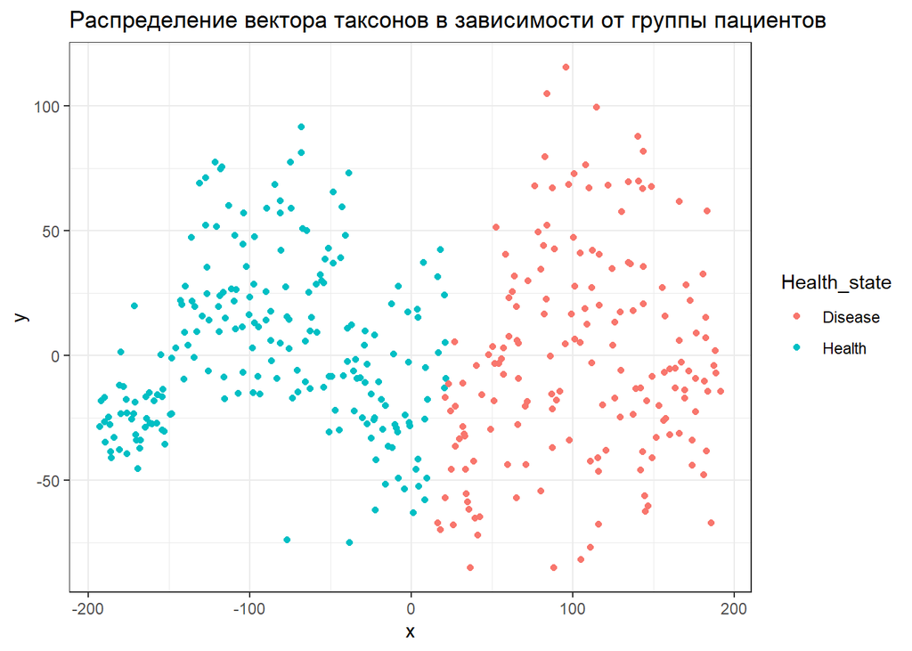

```r
d <- dist(combined_bacteria) # euclidean distances between the rows
fit <- cmdscale(d,eig=TRUE, k=2) # k is the number of dim

df_mds <- data.frame(
  x = fit$points[,1],
  y = fit$points[,2]
  )

df_full <- cbind(df_mds, combined_info) %>% mutate(Health_state_n = case_when(Health_state == "Health"  ~ 0,
                                                                              Health_state == "Disease" ~ 1))

ggplot(df_full, aes(x = x, y = y, color = Health_state)) +
  geom_point() +
  theme_bw() +
  ggtitle("Распределение вектора таксонов в зависимости от группы пациентов")
```

- Используя метод пермутаций проверим отличаются ли группы в зависимомти от Health_state

```r
adonis2(d ~ Health_state_n, data = df_full)
```

```
## Permutation test for adonis under reduced model
## Terms added sequentially (first to last)
## Permutation: free
## Number of permutations: 999
##
## adonis2(formula = d ~ Health_state_n, data = df_full)
##                 Df SumOfSqs      R2      F Pr(>F)
## Health_state_n   1  3433388 0.59834 564.57  0.001 ***
## Residual       379  2304845 0.40166
## Total          380  5738233 1.00000
## ---
## Signif. codes:  0 '***' 0.001 '**' 0.01 '*' 0.05 '.' 0.1 ' ' 1
```

## Тест Манна-Уитни для сравнения каждого таксона между больными и здоровыми

- после округления всех значений **до целого**

```r
Wilcox_comparison_round_0 <- data_wide %>%
  select(Health_state, Archaea, Bacteria,
         ends_with(c("_D", "_P", "_O", "_C", "_F", "_G"))) %>%
  mutate(across (where (is.numeric), function (x) round (x,0))) %>%
  summarise_if (is.numeric, function (x) (wilcox.test(x ~ .$Health_state)$p.value)) %>%
  pivot_longer(everything()) %>%
  rename (Taxon = name, p_value = value) %>%
  filter (p_value <= 0.05 ) %>%
  arrange(p_value) %>%
  add_column(p_value_holm = p.adjust(.$p_value, "holm")) %>%
  add_column(p_value_BH = p.adjust(.$p_value, "BH"))

 rbind (
   "Количество значимо различающихся таксонов по p_value" = nrow (Wilcox_comparison_round_0),
 "Количество значимо различающихся таксонов по p_value_holm" = nrow (Wilcox_comparison_round_0 %>% filter (p_value_holm <= 0.05 )),
 "Количество значимо различающихся таксонов по p_value_BH" = nrow (Wilcox_comparison_round_0 %>% filter (p_value_BH <= 0.05 ))
 )
```

```
##                                                           [,1]
## Количество значимо различающихся таксонов по p_value       141
## Количество значимо различающихся таксонов по p_value_holm   66
## Количество значимо различающихся таксонов по p_value_BH    141
```

- после округления всех значений **до десятых**

```r
Wilcox_comparison_round_1 <- data_wide %>%
  select(Health_state, Archaea, Bacteria,
         ends_with(c("_D", "_P", "_O", "_C", "_F", "_G"))) %>%
  mutate(across (where (is.numeric), function (x) round (x,1))) %>%
  summarise_if (is.numeric, function (x) (wilcox.test(x ~ .$Health_state)$p.value)) %>%
  pivot_longer(everything()) %>%
  rename (Taxon = name, p_value = value) %>%
  filter (p_value <= 0.05 ) %>%
  arrange(p_value) %>%
  add_column(p_value_holm = p.adjust(.$p_value, "holm")) %>%
  add_column(p_value_BH = p.adjust(.$p_value, "BH"))

 rbind (
   "Количество значимо различающихся таксонов по p_value" = nrow (Wilcox_comparison_round_1),
 "Количество значимо различающихся таксонов по p_value_holm" = nrow (Wilcox_comparison_round_1 %>% filter (p_value_holm <= 0.05 )),
 "Количество значимо различающихся таксонов по p_value_BH" = nrow (Wilcox_comparison_round_1 %>% filter (p_value_BH <= 0.05 ))
 )
```

```
##                                                           [,1]
## Количество значимо различающихся таксонов по p_value       319
## Количество значимо различающихся таксонов по p_value_holm  181
## Количество значимо различающихся таксонов по p_value_BH    319
```

- после округления всех значений **до сотых**

```r
Wilcox_comparison_round_2 <- data_wide %>%
  select(Health_state, Archaea, Bacteria,
         ends_with(c("_D", "_P", "_O", "_C", "_F", "_G"))) %>%
  mutate(across (where (is.numeric), function (x) round (x,2))) %>%
  summarise_if (is.numeric, function (x) (wilcox.test(x ~ .$Health_state)$p.value)) %>%
  pivot_longer(everything()) %>%
  rename (Taxon = name, p_value = value) %>%
  filter (p_value <= 0.05 ) %>%
  arrange(p_value) %>%
  add_column(p_value_holm = p.adjust(.$p_value, "holm")) %>%
  add_column(p_value_BH = p.adjust(.$p_value, "BH"))

 rbind (
   "Количество значимо различающихся таксонов по p_value" = nrow (Wilcox_comparison_round_2),
 "Количество значимо различающихся таксонов по p_value_holm" = nrow (Wilcox_comparison_round_2 %>% filter (p_value_holm <= 0.05 )),
 "Количество значимо различающихся таксонов по p_value_BH" = nrow (Wilcox_comparison_round_2 %>% filter (p_value_BH <= 0.05 ))
 )
```

```
##                                                           [,1]
## Количество значимо различающихся таксонов по p_value       646
## Количество значимо различающихся таксонов по p_value_holm  430
## Количество значимо различающихся таксонов по p_value_BH    646
```